# Listener Retention Analysis for a Music Streaming Platform

# Case

A popular music streaming and recommendation service needed to assess listener retention over a three year period (January 2018 - December 2020). The service is offered across a number of platforms: iOS, Android, Roku, Web, Amazon, and several additional ones condensed here into a bucket category All Others. The dataset is limited to a few key variables: `monthly unique listeners`, `daily unique listeners`, and `daily seconds listened` on the service.

# Analysis

## Monthly Unique Listeners

Let’s start by taking a look at the overall volume of monthly unique listeners by platform over the entire three year period. The six platforms are arranged from top to bottom in ascending order of total number of listeners.

Clearly, **most users are on mobile (iOS + Android).** Overall is about 2 million monthly users (3%).

[interactive chart not shown]

## Cyclical engagement

The shape of the above bar graph also suggests **a cyclical pattern of engagement** that repeats each year, which becomes clearer if we zoom in and add lines to mark the start of each year.

Engagement drops throughout the year, reaching its nadir around October before shooting back up through the holiday months.

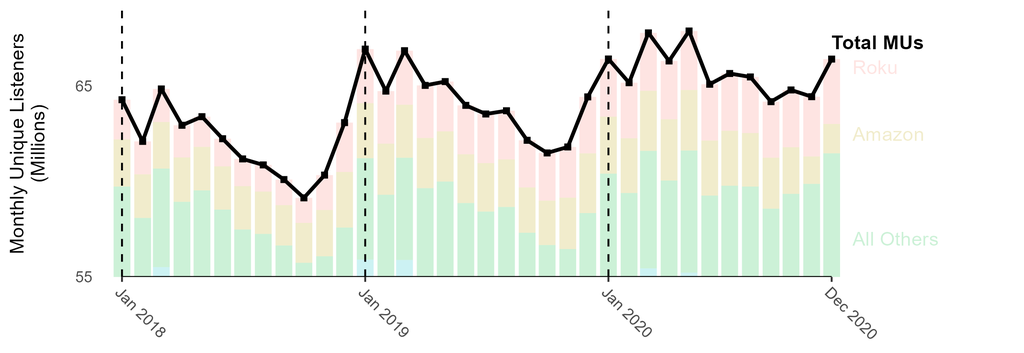

## Growth Trends by Platform

Plotting the same listener data so that we can more easily compare retention across platforms (the plot on the left below) makes clear that **retention trends vary substantially by platform**. iOS, Roku, and All Others show positive retention, while Android and Web show losses.

Could these differences owe to differing rates of new user acquisition between platforms? The cumulative data on the right shows this isn’t the case. Scroll through the plots below for more detail.

[interactive chart not shown]

## Devising a new retention metric

The dataset only includes a small number of measures (`monthly unique listeners`, `daily unique listeners`, and `daily seconds listened`). Can we devise a more informative metric than listener counts from the available data that will tell us something more about our listeners?

One possibility to is to calculate the *average number of days used per monthly unique listener*, or **active days per month (ADM):**

$$\text{ADM} =\frac{\text{sum # of unique daily listeners for entire month}}{ \text{# unique listeners for that month}}$$

In other words, how many days per month did the typical listener use the service? What does this metric tell us that’s new and useful?

1. It it assesses *purposeful behavior.* Measuring the extent to which listeners *choose* to return to the service each month can serve as a proxy of satisfaction and service “stickiness.”
2. As metrics should be, it is easy to understand and compare across platforms
3. It measures the same thing across platforms: purposeful behavior by the user to sign in

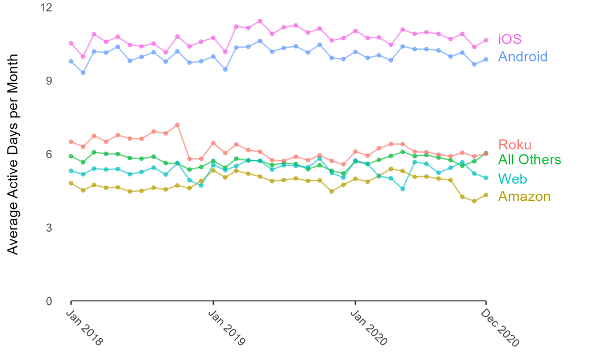

Clearly, **the most active users are on mobile.** iOS users listened an average of 10.8 days per month overall, while Amazon users only listened about 4.8 times per month.

## Listening Time

One shortcoming of our ADU metric is that it doesn’t tell us anything about how long users are listening for. The length of the average listening session per daily unique is plotted below, where each dot represents a single day, and a smoothed best-fit line has been added.

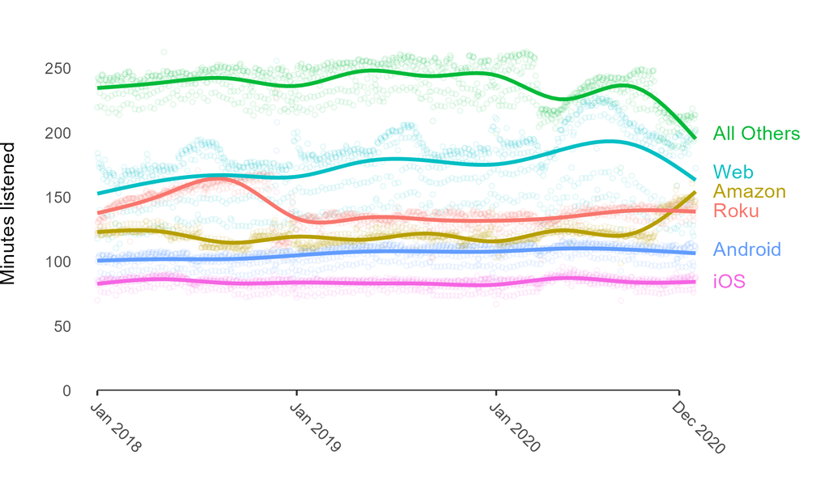

This plot looks like a mirror image of our ADM plot immediately above! That is, while iOS and Android users return to the service most frequently overall (as shown above), they also listen for the shortest amount of time per session (84.1 and 106 minutes overall, respectively). Conversely, users return to the web platform much less often , but listen for longer periods (174 minutes, on average). Thus, **ADM and listening time appear inversely related**.

Let’s dig a little more for differences and take a look at the overall distribution of listening times for each platform:

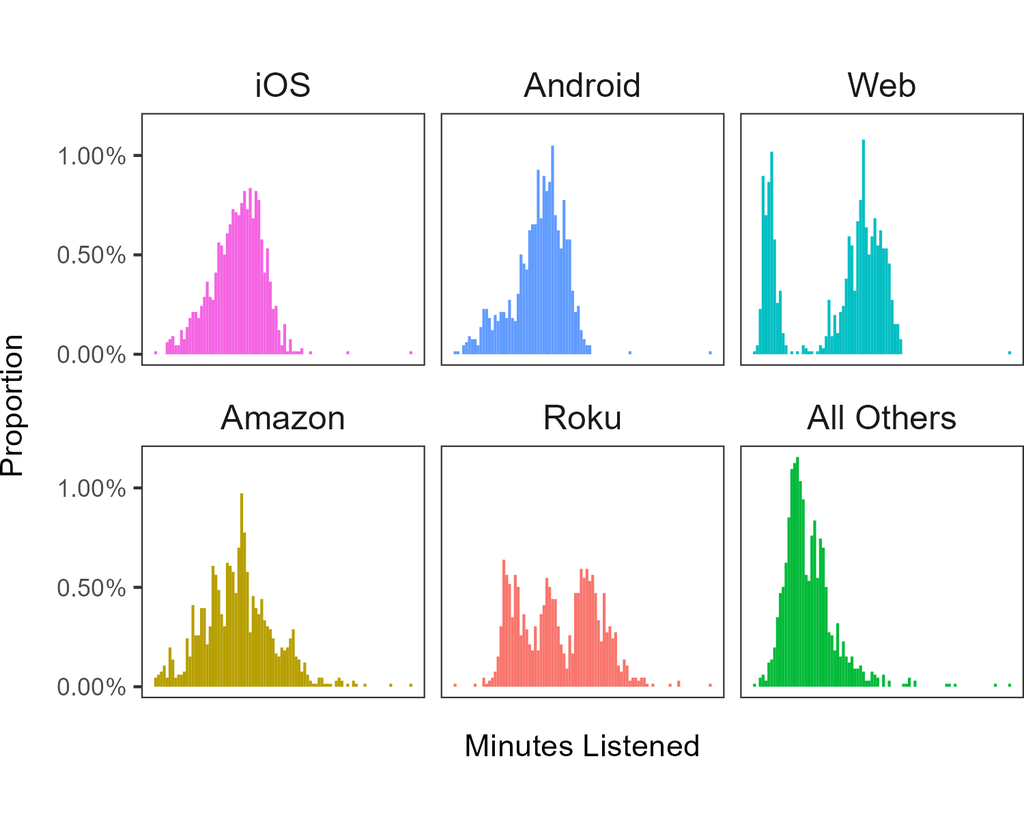

Here too, additional differences by platform emerge. While iOS, Android, and All Others listening times are roughly normally distributed, Web sessions appear split between short and longer sessions, and Roku listening times cluster into short, medium, and long sessions.

# Summary

Our analysis has revealed some interesting patterns and opportunities for growth:

- **Overall retention is low but varies subtantially by platform**. From 2018 to 2020, the number of monthly users increased by only 3%. Some platforms show strong retention (e.g., iOS), while others are losing users (Android, Web).
- **New user acquisition does not predict retention.** iOS and Android gained new listeners at equal rates, but only iOS retained those users over the three years analyzed. Web was the platform with the highest rate of both new user acquisition and monthly listener loss!
- **Engagement is cyclical.** All platforms appear to decline from early-year peaks in engagement before recovering during the holiday season.
- **Possible platform-specific issues**. The difference in retention between iOS and Android is surprising considering that both are mobile platforms that are likely used in similar situations. This suggests an Android-specific issue in need of further investigation.
- **Behavior differences across platforms**. The platforms where users returned most often throughout the month also tended to have the shortest average listening times, and vice versa for those returned to less frequently. This may be due to different usage occasions (e.g., playing music in the background at party on a smart device using Roku)

Back to portfolio